# Prediction of Winning / Elimination Week

Import Dependencies

```python
# special IPython command to prepare the notebook for matplotlib
%matplotlib inline

import numpy as np
import pandas as pd
import scipy.stats as stats
import matplotlib.pyplot as plt
import sklearn
import statsmodels.api as sm

import seaborn as sns
sns.set_style("whitegrid")
sns.set_context("poster")

# special matplotlib argument for improved plots
from matplotlib import rcParams


import scipy as sp
import matplotlib as mpl
import matplotlib.cm as cm
import time
pd.set_option('display.width', 500)
pd.set_option('display.max_columns', 100)
pd.set_option('display.notebook_repr_html', True)
import seaborn as sns
sns.set_style("whitegrid")
sns.set_context("poster")
import requests
import json
import math

from sklearn.grid_search import GridSearchCV
from sklearn.metrics import confusion_matrix
from sklearn.cross_validation import train_test_split
from sklearn.linear_model import *

from sklearn.metrics import roc_curve, auc

# import helper commands
from helpers import *
```

## Import Data

```python
#Import all data sources

#Data for each contestant broken down by seasons
with open('tempdata/seasonsDict.json') as json_file:
    seasonsDict = json.load(json_file)

#Twitter
with open("twitter_sentiment.json") as json_file:
    twitter = json.load(json_file)

#Distances
with open("distances.json") as json_file:
    distances = json.load(json_file)

#Geo-Cluster
with open("geo_cluster.json") as json_file:
    geo_cluster = json.load(json_file)

#Profession
with open("profession_dict.json") as json_file:
    professions = json.load(json_file)

#Wiki Info
wiki = pd.read_csv("contestantDF.csv")

#Date Guide
date_guide = pd.read_csv("date_guide.csv")

# PCA data
with open('pca_dict.json') as json_file:
    raw_pca_data = json.load(json_file)

pca_data = {}
for sn in distances:
    pca_data[sn] = {}
    for contestant in distances[sn]:
        for c in raw_pca_data[sn]:
            if c in contestant:
                pca_data[sn][contestant] = raw_pca_data[sn][c]

#Competition Data
with open("competition_data.json") as json_file:
    comp = json.load(json_file)
```

## Aggregate Data to be Used in DF

```python
# Organize all the data into a single list
contestants = []
for sn in seasonsDict:
    if int(sn) > 12: # only add data from seasons 13 and on
        for contestant in seasonsDict[sn]:
            cname = contestant['name']
            # add twitter data to contestants info
            foundTwitterName = False
            for tname in twitter[sn]:
                if tname in cname:
                    if len(twitter[sn][tname]) > 0:
                        ntweets = []
                        tweetSentiment = []
                        for date in twitter[sn][tname]:
                            ntweets.append(twitter[sn][tname][date]['ntweet'])
                            tweetSentiment.append(twitter[sn][tname][date]['sentiment'])
                        contestant['avg_num_tweets'] = np.mean(ntweets)
                        contestant['total_tweets'] = np.sum(ntweets)
                        contestant['avg_tweet_sentiment'] = np.mean(tweetSentiment)
                        contestant['total_tweet_sentiment'] = np.sum(tweetSentiment)
                    else:
                        contestant['avg_num_tweets'] = 0
                        contestant['total_tweets'] =0
                        contestant['avg_tweet_sentiment'] = 0
                        contestant['total_tweet_sentiment'] = 0

            if cname in distances[sn]:
                # add distance data
                contestant['distance'] = distances[sn][cname]

                # add profession data

                contestant['profession'] = professions[sn][cname]

                # add geo cluster data
                contestant['geo_cluster'] = geo_cluster[sn][cname]
                if cname in pca_data[sn]:
                    contestant['pc1'], contestant['pc2'] = pca_data[sn][cname]

                contestants.append(contestant)
```

## Generate DF for All Data

```python
# Create data frame from the contestants dictionary
df = pd.DataFrame(contestants)

# get rid of an samples that contain NaN
#df = df.dropna()
# just in case, we drop any duplicate samples
df = df.drop_duplicates()
# get rid of the samples for bachelors
df = df[df.elimination != 'unknown']
# create a column for 'won' to indicate whether the contestant won or did not
df['won'] = (df.elimination == 'Winner')*1
df['runner_up'] = (df.elimination == 'Runner-up')*1
# winners and runners up are currently strings. We need to turn them into integers
df['elimination'] = df['elimination'].apply(change_winner_runnerup)
df['elimination'] = df['elimination'].astype('int')
# create a dataframe where the unecessary columns are droped
df_temp = df.drop(['hometown','name','occupation','season','pc1','pc2'],1)
df_temp.head(10)
```

|  | age | avg_num_tweets | avg_tweet_sentiment | distance | elimination | geo_cluster | group_dates | individual_dates | profession | roses_from_group_dates | roses_from_individual_dates | total_tweet_sentiment | total_tweets | won | runner_up |
| --- | --- | --- | --- | --- | --- | --- | --- | --- | --- | --- | --- | --- | --- | --- | --- |
| 0 | 25 | 13.285714 | 0.179650 | 1025.064422 | 10 | 5 | 2 | 1 | 5 | 0 | 1 | 1.257547 | 93 | 1 | 0 |
| 1 | 24 | 10.285714 | 0.071815 | 226.889927 | 9 | 4 | 1 | 1 | 3 | 1 | 1 | 0.502707 | 72 | 0 | 1 |
| 2 | 29 | 5.333333 | -0.073958 | 1879.977325 | 7 | 7 | 2 | 1 | 2 | 0 | 0 | -0.443750 | 32 | 0 | 0 |
| 3 | 24 | 1.200000 | 0.005556 | 2026.201031 | 6 | 6 | 3 | 0 | 5 | 1 | 0 | 0.027778 | 6 | 0 | 0 |
| 4 | 34 | 4.000000 | 0.062500 | 538.679446 | 5 | 3 | 0 | 2 | 3 | 0 | 2 | 0.250000 | 16 | 0 | 0 |
| 5 | 27 | 0.666667 | -0.166667 | 397.346118 | 4 | 2 | 2 | 0 | 2 | 0 | 0 | -0.500000 | 2 | 0 | 0 |
| 6 | 25 | 2.666667 | -0.066667 | 103.284845 | 4 | 1 | 2 | 0 | 3 | 0 | 0 | -0.200000 | 8 | 0 | 0 |
| 7 | 29 | 2.000000 | 0.166667 | 627.494033 | 4 | 5 | 2 | 0 | 3 | 0 | 0 | 0.500000 | 6 | 0 | 0 |
| 8 | 29 | 0.000000 | 0.000000 | 309.413472 | 4 | 4 | 0 | 0 | 3 | 0 | 0 | 0.000000 | 0 | 0 | 0 |
| 9 | 25 | 0.500000 | 0.000000 | 439.699607 | 3 | 1 | 2 | 0 | 1 | 0 | 0 | 0.000000 | 1 | 0 | 0 |

#### Get the shape of data

```python
df_temp.shape
```

```
(188, 15)
```

#### Get the summary statistics for each of the columns

```python
df_temp.describe()
```

|  | avg_num_tweets | avg_tweet_sentiment | distance | elimination | geo_cluster | group_dates | individual_dates | profession | roses_from_group_dates | roses_from_individual_dates | total_tweet_sentiment | total_tweets | won | runner_up |
| --- | --- | --- | --- | --- | --- | --- | --- | --- | --- | --- | --- | --- | --- | --- |
| count | 187.000000 | 187.000000 | 188.000000 | 188.000000 | 188.000000 | 188.000000 | 188.000000 | 188.000000 | 188.000000 | 188.000000 | 187.000000 | 187.000000 | 188.000000 | 188.000000 |
| mean | 69.345355 | -0.004858 | 1167.517340 | 3.776596 | 3.909574 | 1.446809 | 0.292553 | 8.367021 | 0.175532 | 0.276596 | -0.015337 | 322.203209 | 0.037234 | 0.037234 |
| std | 77.579937 | 0.056251 | 781.632641 | 2.787114 | 1.922931 | 1.531257 | 0.521770 | 72.654838 | 0.457892 | 0.515104 | 0.224103 | 460.825955 | 0.189840 | 0.189840 |
| min | 0.000000 | -0.232394 | 86.282895 | 1.000000 | 1.000000 | 0.000000 | 0.000000 | 1.000000 | 0.000000 | 0.000000 | -1.311356 | 0.000000 | 0.000000 | 0.000000 |
| 25% | 0.000000 | -0.019816 | 660.512782 | 1.000000 | 2.000000 | 0.000000 | 0.000000 | 2.000000 | 0.000000 | 0.000000 | -0.068591 | 0.000000 | 0.000000 | 0.000000 |
| 50% | 21.000000 | 0.000000 | 1054.494144 | 3.000000 | 4.000000 | 1.000000 | 0.000000 | 3.000000 | 0.000000 | 0.000000 | 0.000000 | 65.000000 | 0.000000 | 0.000000 |
| 75% | 151.482143 | 0.005344 | 1535.580050 | 6.000000 | 6.000000 | 3.000000 | 1.000000 | 5.000000 | 0.000000 | 0.000000 | 0.024874 | 528.000000 | 0.000000 | 0.000000 |
| max | 200.000000 | 0.250000 | 5323.980053 | 10.000000 | 7.000000 | 5.000000 | 2.000000 | 999.000000 | 3.000000 | 2.000000 | 1.257547 | 1714.000000 | 1.000000 | 1.000000 |

#### Look at any correlations between variables.

We particularly look at the correlation between dependent variables and the elimination week for each contestant as well as whether that contestant won the entire competition

```python
df.corr().won
```

```
avg_num_tweets                 0.220814
avg_tweet_sentiment            0.007494
distance                      -0.043893
elimination                    0.440292
geo_cluster                    0.009272
group_dates                    0.181611
individual_dates               0.267352
pc1                           -0.200772
pc2                           -0.103522
profession                    -0.014954
roses_from_group_dates         0.170485
roses_from_individual_dates    0.276920
season                        -0.007815
total_tweet_sentiment         -0.014137
total_tweets                   0.410360
won                            1.000000
runner_up                     -0.038674
Name: won, dtype: float64
```

We look primarily at those variables that are correlated with winning the entire competition and those correleated with a higher elimination week.

Those variables with a higher positive correlation with winning the entire competition where average number of tweets, the number of total individual and group dates as well as the number of roses acquired from these dates.

```python
df.corr().elimination
```

```
avg_num_tweets                 0.611631
avg_tweet_sentiment           -0.020639
distance                      -0.084877
elimination                    1.000000
geo_cluster                    0.006188
group_dates                    0.742743
individual_dates               0.673995
pc1                           -0.053224
pc2                           -0.195776
profession                     0.031437
roses_from_group_dates         0.525342
roses_from_individual_dates    0.657872
season                         0.113756
total_tweet_sentiment         -0.023664
total_tweets                   0.803922
won                            0.440292
runner_up                      0.369544
Name: elimination, dtype: float64
```

Those variables with a higer positive correlation with higher elimination weeks were the same as those variables that correlated with winning the entire competition. The correlation between these dependent variables and the elimination week, howerver, were almost three times greater than the correlation between the same dependent variables and winning the competition.

#### Correlation between average number of tweets and elimination week

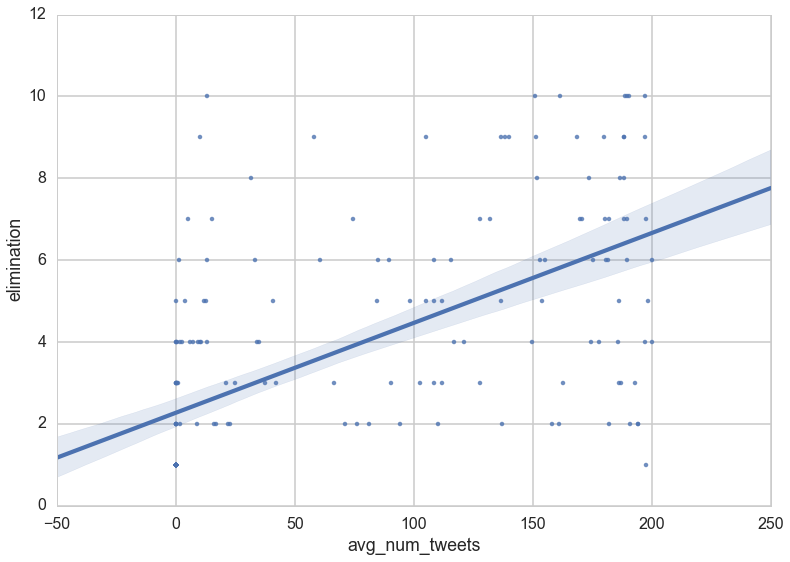

```python
sns.regplot(y="elimination", x="avg_num_tweets", data=df, fit_reg = True)
```

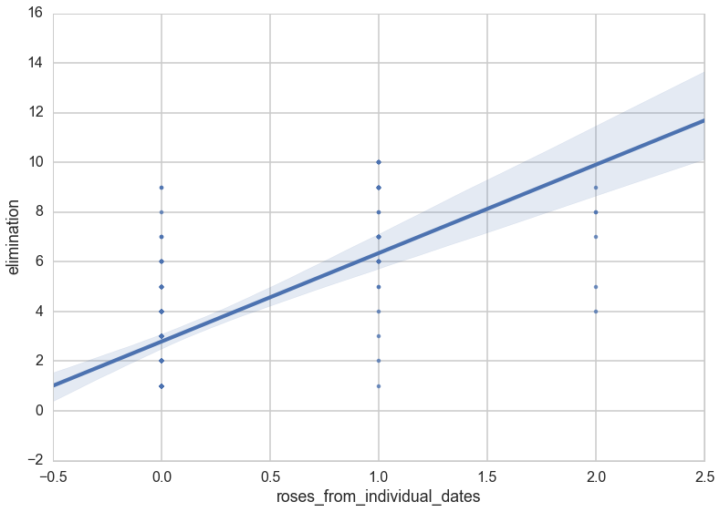

```python
sns.regplot(y="elimination", x="roses_from_individual_dates", data=df, fit_reg = True)
```

## Looking at the Correlation between Dependent Variables

We attempt to vizualize the correlation between dependent variables that are positively correlated with the independent variables

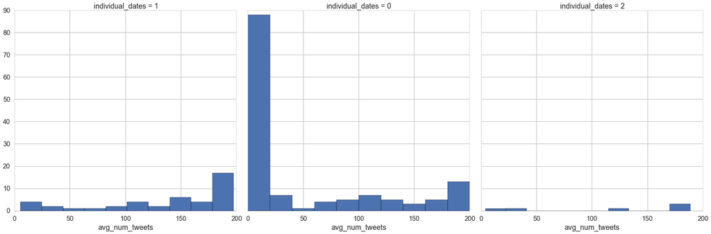

```python
# Plot histogram of number of tweets broken up by individual dates
g = sns.FacetGrid(col="individual_dates", data=df, size=8)
g.map(plt.hist, "avg_num_tweets")
```

There is a higher distribution of tweets for those individuals that received individual dates.

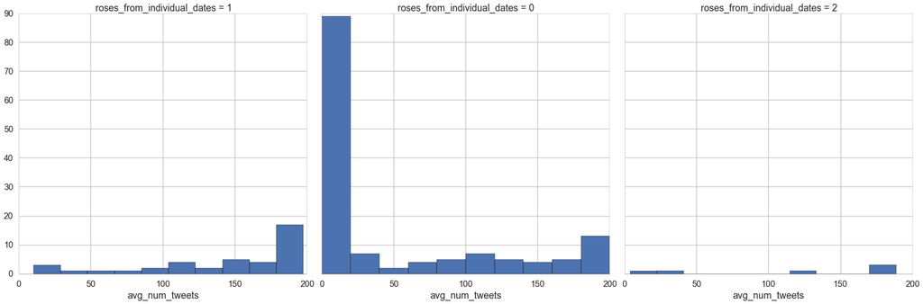

```python
# Plot histogram of number of tweets broken up by individual dates
g = sns.FacetGrid(col="roses_from_individual_dates", data=df, size=8)
g.map(plt.hist, "avg_num_tweets")
```

Likewise, there is a higher distribution of tweets for those that candidates that received a rose from individual dates.

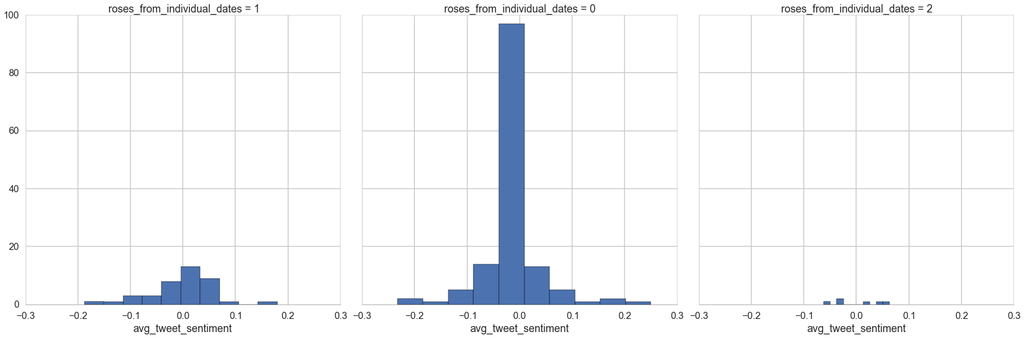

```python
# Plot histogram of number of tweets broken up by
g = sns.FacetGrid(col="roses_from_individual_dates", data=df, size=8)
g.map(plt.hist, "avg_tweet_sentiment")
```

We also look to see if roses from individual dates had a higher distribution of contestants that had higher avgerage twitter sentiment. Theres a relatively higher distribution of contestants who received roses from individual dates and received had higher twitter sentiments.

## Run Logistic Regression on Data

We want to run a logistics regression to determine the probability of a contestant winning the competition.

```python
# fit logistic regression model
import statsmodels.api as sm
from statsmodels.formula.api import logit, glm, ols

logit_model = logit('won ~ avg_num_tweets + roses_from_individual_dates',df).fit()
logit_model.summary()
```

```
Optimization terminated successfully.
         Current function value: 0.123483
         Iterations 9
```

Logit Regression Results

| Dep. Variable: | won | No. Observations: | 187 |
| --- | --- | --- | --- |
| Model: | Logit | Df Residuals: | 184 |
| Method: | MLE | Df Model: | 2 |
| Date: | Thu, 10 Dec 2015 | Pseudo R-squ.: | 0.2268 |
| Time: | 17:42:42 | Log-Likelihood: | -23.091 |
| converged: | True | LL-Null: | -29.864 |
|  |  | LLR p-value: | 0.001145 |

|  | coef | std err | z | P>\|z\| | [95.0% Conf. Int.] |
| --- | --- | --- | --- | --- | --- |
| Intercept | -5.5503 | 1.229 | -4.515 | 0.000 | -7.960 -3.141 |
| avg_num_tweets | 0.0126 | 0.007 | 1.695 | 0.090 | -0.002 0.027 |
| roses_from_individual_dates | 1.3700 | 0.655 | 2.092 | 0.036 | 0.086 2.654 |

## Run a Linear Regression on Data

We want to run a linear regression to estimate a contestants elimination week

```python
model = ols('elimination ~ avg_num_tweets + roses_from_individual_dates + roses_from_group_dates + pc2 ',df).fit()
model.summary()
```

OLS Regression Results

| Dep. Variable: | elimination | R-squared: | 0.609 |
| --- | --- | --- | --- |
| Model: | OLS | Adj. R-squared: | 0.597 |
| Method: | Least Squares | F-statistic: | 54.41 |
| Date: | Thu, 10 Dec 2015 | Prob (F-statistic): | 1.34e-27 |
| Time: | 17:42:42 | Log-Likelihood: | -280.49 |
| No. Observations: | 145 | AIC: | 571.0 |
| Df Residuals: | 140 | BIC: | 585.9 |
| Df Model: | 4 |  |  |
| Covariance Type: | nonrobust |  |  |

|  | coef | std err | t | P>\|t\| | [95.0% Conf. Int.] |
| --- | --- | --- | --- | --- | --- |
| Intercept | 2.0989 | 0.187 | 11.240 | 0.000 | 1.730 2.468 |
| avg_num_tweets | 0.0118 | 0.002 | 5.310 | 0.000 | 0.007 0.016 |
| roses_from_individual_dates | 1.7241 | 0.333 | 5.184 | 0.000 | 1.067 2.382 |
| roses_from_group_dates | 1.5851 | 0.357 | 4.446 | 0.000 | 0.880 2.290 |
| pc2 | -9.162e-05 | 4.85e-05 | -1.891 | 0.061 | -0.000 4.18e-06 |

| Omnibus: | 6.635 | Durbin-Watson: | 1.181 |
| --- | --- | --- | --- |
| Prob(Omnibus): | 0.036 | Jarque-Bera (JB): | 9.573 |
| Skew: | 0.197 | Prob(JB): | 0.00834 |
| Kurtosis: | 4.195 | Cond. No. | 8.32e+03 |

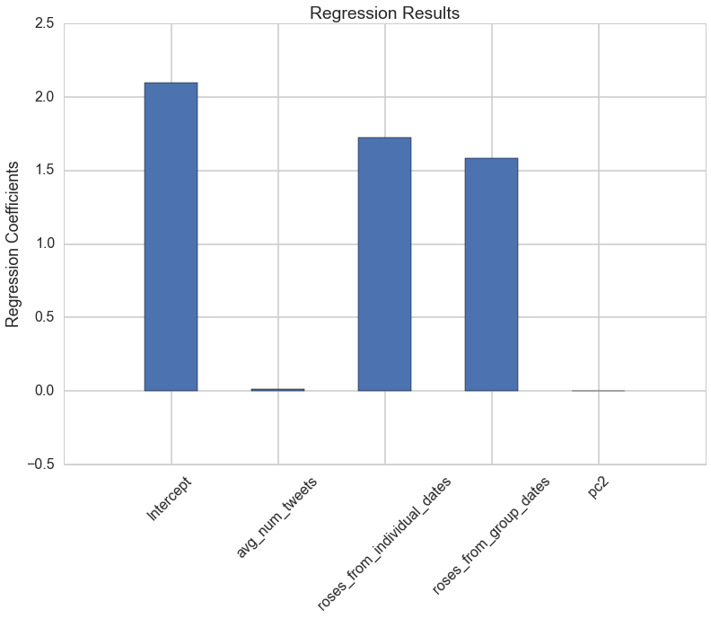

```python
features = list(model.params.keys())
coefs = list(model.params.values)
plt.bar(range(len(features)),coefs, align="center", width=.5)
plt.xticks(range(len(features)), features, rotation=45)
plt.ylabel("Regression Coefficients")
plt.title("Regression Results")
plt.show()
```

## Breakdown Data by Season

We want to breakdown the data by season to account for the differences in the number of tweets from each season, since the average number of tweets about all contestants should increase from year to year due to twitter's broader addoption.

```python
seasons_dfs = {}
for sn in range(13,20):
    seasons_dfs[sn] = df_temp[df['season'] == sn]
```

```python
seasons_dfs[14].head()
```

|  | age | avg_num_tweets | avg_tweet_sentiment | distance | elimination | geo_cluster | group_dates | individual_dates | profession | roses_from_group_dates | roses_from_individual_dates | total_tweet_sentiment | total_tweets | won | runner_up |
| --- | --- | --- | --- | --- | --- | --- | --- | --- | --- | --- | --- | --- | --- | --- | --- |
| 55 | 23 | 151.000000 | -0.187337 | 970.915710 | 10 | 3 | 2 | 1 | 1 | 0 | 1 | -1.311356 | 1057 | 1 | 0 |
| 56 | 25 | 140.142857 | 0.006997 | 1638.689701 | 9 | 6 | 1 | 0 | 2 | 1 | 0 | 0.048978 | 981 | 0 | 1 |
| 57 | 26 | 74.666667 | -0.048547 | 1371.988917 | 7 | 1 | 1 | 1 | 5 | 0 | 1 | -0.291285 | 448 | 0 | 0 |
| 58 | 25 | 108.400000 | -0.012097 | 1453.479117 | 6 | 1 | 1 | 1 | 1 | 0 | 1 | -0.060484 | 542 | 0 | 0 |
| 59 | 23 | 12.750000 | 0.014583 | 965.750991 | 5 | 3 | 2 | 0 | 4 | 0 | 0 | 0.058333 | 51 | 0 | 0 |

```python
seasons_dfs[14].corr().won
```

```
avg_num_tweets                 0.454344
avg_tweet_sentiment           -0.453450
distance                      -0.024731
elimination                    0.554021
geo_cluster                   -0.082479
group_dates                    0.374192
individual_dates               0.302849
profession                    -0.223972
roses_from_group_dates        -0.060193
roses_from_individual_dates    0.302849
total_tweet_sentiment         -0.849981
total_tweets                   0.628029
won                            1.000000
runner_up                     -0.041667
Name: won, dtype: float64
```

```python
seasons_dfs[14].corr().elimination
```

```
avg_num_tweets                 0.726037
avg_tweet_sentiment           -0.376984
distance                       0.402683
elimination                    1.000000
geo_cluster                   -0.170559
group_dates                    0.661066
individual_dates               0.501505
profession                    -0.176804
roses_from_group_dates         0.276867
roses_from_individual_dates    0.501505
total_tweet_sentiment         -0.583122
total_tweets                   0.881673
won                            0.554021
runner_up                      0.473494
Name: elimination, dtype: float64
```

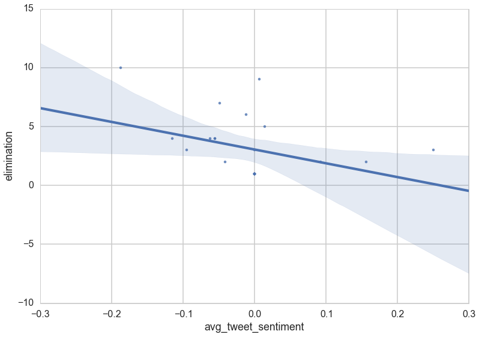

```python
sns.regplot(y="elimination", x="avg_tweet_sentiment", data=seasons_dfs[14], fit_reg = True)
```

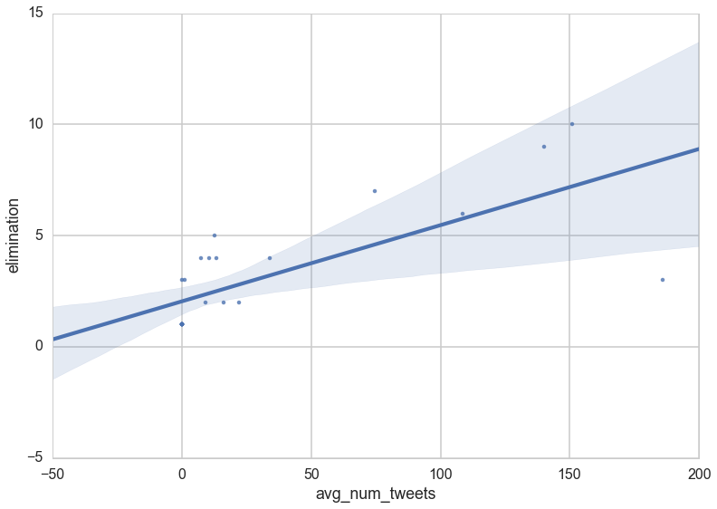

```python
sns.regplot(y="elimination", x="avg_num_tweets", data=seasons_dfs[14], fit_reg = True)
```